# Assignment 4 K-means for clustering

Avinash Ravipudi

2022-11-04

```r
#install.packages("httr")
#install.packages("readr")
#install.packages("factoextra")
#install.packages("flexclust")
library(httr)
library(readr)
library(tidyverse)
library(factoextra)
library(ISLR)
library(flexclust)
library(caret)
```

#Importing Data set

```r
#importing Data set and converting
getwd()
```

```
## [1] "/Users/avinashravipudi/Documents/FML/Assignment - 4 "
```

```r
pharma<-read.csv("Pharmaceuticals.csv")
#summarize the Data
#str(pharma)
head(pharma,10)
```

```
##    Symbol                         Name Market_Cap Beta PE_Ratio  ROE  ROA
## 1     ABT          Abbott Laboratories      68.44 0.32     24.7 26.4 11.8
## 2     AGN               Allergan, Inc.       7.58 0.41     82.5 12.9  5.5
## 3     AHM                 Amersham plc       6.30 0.46     20.7 14.9  7.8
## 4     AZN              AstraZeneca PLC      67.63 0.52     21.5 27.4 15.4
## 5     AVE                      Aventis      47.16 0.32     20.1 21.8  7.5
## 6     BAY                     Bayer AG      16.90 1.11     27.9  3.9  1.4
## 7     BMY Bristol-Myers Squibb Company      51.33 0.50     13.9 34.8 15.1
## 8    CHTT                 Chattem, Inc       0.41 0.85     26.0 24.1  4.3
## 9     ELN        Elan Corporation, plc       0.78 1.08      3.6 15.1  5.1
## 10    LLY        Eli Lilly and Company      73.84 0.18     27.9 31.0 13.5
##    Asset_Turnover Leverage Rev_Growth Net_Profit_Margin Median_Recommendation
## 1             0.7     0.42       7.54              16.1          Moderate Buy
## 2             0.9     0.60       9.16               5.5          Moderate Buy
## 3             0.9     0.27       7.05              11.2            Strong Buy
```

[output cut: 18 more lines]

```r
set.seed(23)
#Data frame  Z Score scaling
pharma_scaled <- scale(pharma[,3:11])
summary(pharma_scaled)
```

```
##    Market_Cap           Beta            PE_Ratio            ROE
##  Min.   :-0.9768   Min.   :-1.3466   Min.   :-1.3404   Min.   :-1.4515
##  1st Qu.:-0.8763   1st Qu.:-0.6844   1st Qu.:-0.4023   1st Qu.:-0.7223
##  Median :-0.1614   Median :-0.2560   Median :-0.2429   Median :-0.2118
##  Mean   : 0.0000   Mean   : 0.0000   Mean   : 0.0000   Mean   : 0.0000
##  3rd Qu.: 0.2762   3rd Qu.: 0.4841   3rd Qu.: 0.1495   3rd Qu.: 0.3450
##  Max.   : 2.4200   Max.   : 2.2758   Max.   : 3.4971   Max.   : 2.4597
##       ROA          Asset_Turnover       Leverage          Rev_Growth
##  Min.   :-1.7128   Min.   :-1.8451   Min.   :-0.74966   Min.   :-1.4971
##  1st Qu.:-0.9047   1st Qu.:-0.4613   1st Qu.:-0.54487   1st Qu.:-0.6328
##  Median : 0.1289   Median :-0.4613   Median :-0.31449   Median :-0.3621
##  Mean   : 0.0000   Mean   : 0.0000   Mean   : 0.00000   Mean   : 0.0000
##  3rd Qu.: 0.8430   3rd Qu.: 0.9225   3rd Qu.: 0.01828   3rd Qu.: 0.7693
##  Max.   : 1.8389   Max.   : 1.8451   Max.   : 3.74280   Max.   : 1.8862
##  Net_Profit_Margin
##  Min.   :-1.99560
##  1st Qu.:-0.68504
##  Median : 0.06168
##  Mean   : 0.00000
##  3rd Qu.: 0.82364
##  Max.   : 1.49416
```

```r
# Data Frame Range Scaling
pharma_range <- scale(pharma[,3:11])
```

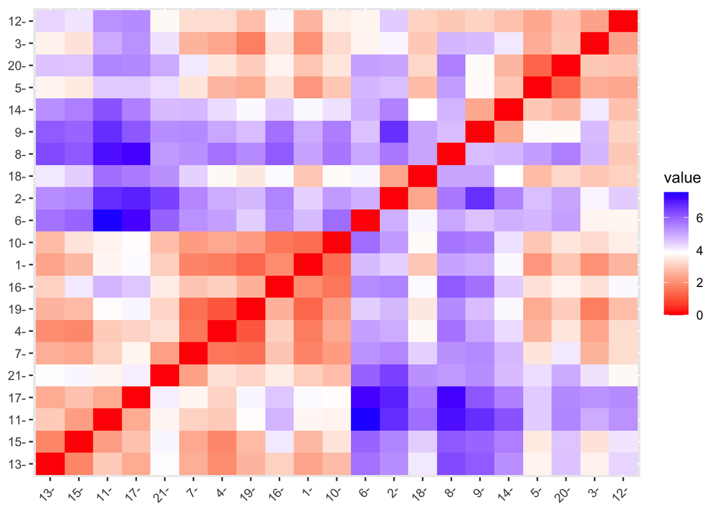

```r
set.seed(23)
dst_rows <- get_dist(pharma_scaled)
fviz_dist(dst_rows) #To visualize distance between matrix rows
```

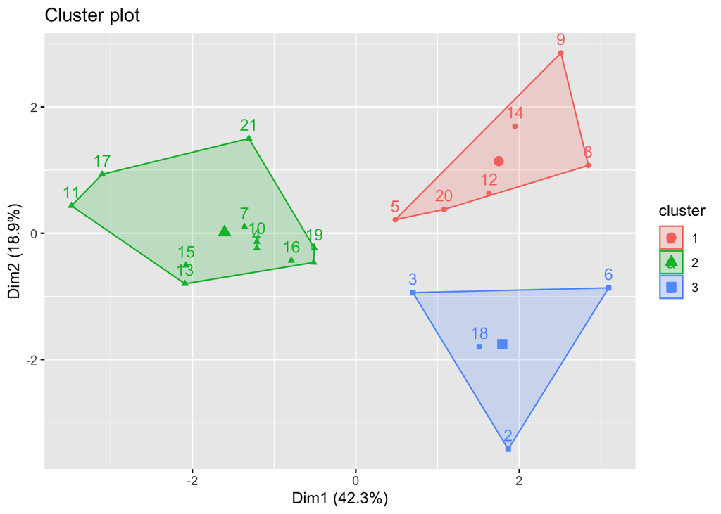

```r
cluster1 <- kmeans(pharma_scaled, centers = 3, nstart = 15) # HEre taking K=3 & nstart=15
fviz_cluster(cluster1, data = pharma_scaled)
```

```r
print(cluster1)
```

```
## K-means clustering with 3 clusters of sizes 6, 11, 4
##
## Cluster means:
##   Market_Cap       Beta   PE_Ratio        ROE        ROA Asset_Turnover
## 1 -0.8261772  0.4775991 -0.3696184 -0.5631589 -0.8514589     -0.9994088
## 2  0.6733825 -0.3586419 -0.2763512  0.6565978  0.8344159      0.4612656
## 3 -0.6125361  0.2698666  1.3143935 -0.9609057 -1.0174553      0.2306328
##     Leverage Rev_Growth Net_Profit_Margin
## 1  0.8502201  0.9158889        -0.3319956
## 2 -0.3331068 -0.2902163         0.6823310
## 3 -0.3592866 -0.5757385        -1.3784169
##
## Clustering vector:
##  [1] 2 3 3 2 1 3 2 1 1 2 2 1 2 1 2 2 2 3 2 1 2
##
## Within cluster sum of squares by cluster:
## [1] 32.14336 43.30886 20.54199
##  (between_SS / total_SS =  46.7 %)
##
## Available components:
##
## [1] "cluster"      "centers"      "totss"        "withinss"     "tot.withinss"
## [6] "betweenss"    "size"         "iter"         "ifault"
```

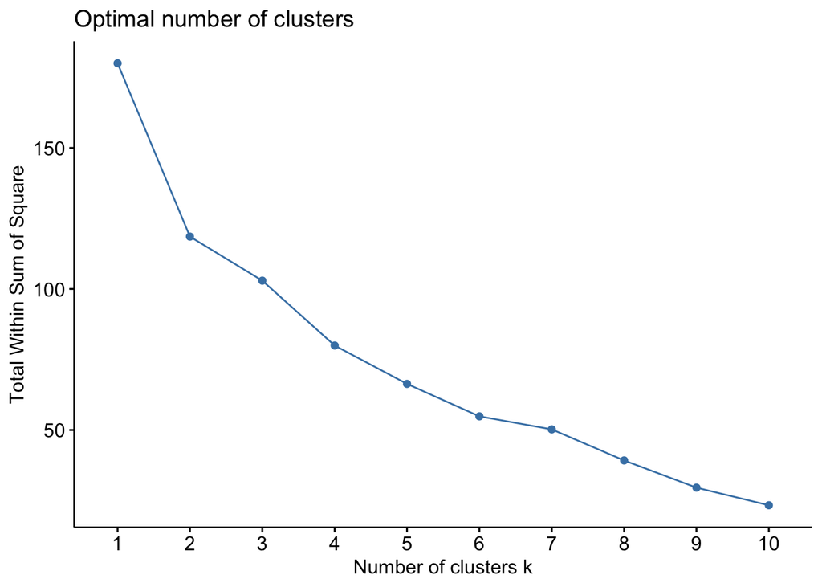

```r
fviz_nbclust(pharma_scaled, kmeans, method = "wss") # WSS method (ELBOW METHOOD)
```

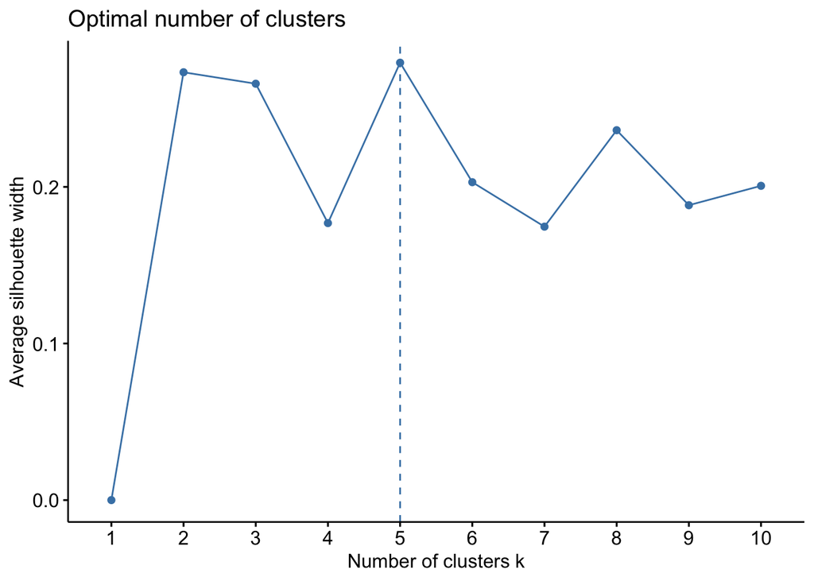

```r
fviz_nbclust(pharma_scaled, kmeans, method = "silhouette") #SILHOUETTE Methood (To find best K value)
```

I did not use the WSS approach since the graph did not show a distinct elbow and was extremely unclear. The graph does not indicate the elbow/knee position, and it flattens out more than once at k = 4 and 6, respectively, and I chose the silhouette approach since it is apparent to display the ideal cluster K = 5.

```r
#let's look at the mean value from actual data by clusters
aggregate(pharma[3:11], by=list(cluster=cluster1$cluster), mean)
```

```
##   cluster Market_Cap      Beta PE_Ratio  ROE       ROA Asset_Turnover  Leverage
## 1       1    9.23500 0.6483333 19.43333 17.3  5.983333      0.4833333 1.2500000
## 2       2   97.11364 0.4336364 20.95455 35.7 14.954545      0.8000000 0.3254545
## 3       3   21.75500 0.5950000 46.90000 11.3  5.100000      0.7500000 0.3050000
##   Rev_Growth Net_Profit_Margin
## 1   23.49000          13.51667
## 2   10.16455          20.17273
## 3    7.01000           6.65000
```

```r
actual_data <- cbind(pharma, cluster = cluster1$cluster)
tibble(actual_data)
```

```
## # A tibble: 21 × 15
##    Symbol Name         Marke…¹  Beta PE_Ra…²   ROE   ROA Asset…³ Lever…⁴ Rev_G…⁵
##    <chr>  <chr>          <dbl> <dbl>   <dbl> <dbl> <dbl>   <dbl>   <dbl>   <dbl>
##  1 ABT    Abbott Labo…   68.4   0.32    24.7  26.4  11.8     0.7    0.42    7.54
##  2 AGN    Allergan, I…    7.58  0.41    82.5  12.9   5.5     0.9    0.6     9.16
##  3 AHM    Amersham plc    6.3   0.46    20.7  14.9   7.8     0.9    0.27    7.05
##  4 AZN    AstraZeneca…   67.6   0.52    21.5  27.4  15.4     0.9    0      15
##  5 AVE    Aventis        47.2   0.32    20.1  21.8   7.5     0.6    0.34   26.8
##  6 BAY    Bayer AG       16.9   1.11    27.9   3.9   1.4     0.6    0      -3.17
##  7 BMY    Bristol-Mye…   51.3   0.5     13.9  34.8  15.1     0.9    0.57    2.7
##  8 CHTT   Chattem, Inc    0.41  0.85    26    24.1   4.3     0.6    3.51    6.38
##  9 ELN    Elan Corpor…    0.78  1.08     3.6  15.1   5.1     0.3    1.07   34.2
## 10 LLY    Eli Lilly a…   73.8   0.18    27.9  31    13.5     0.6    0.53    6.21
## # … with 11 more rows, 5 more variables: Net_Profit_Margin <dbl>,
## #   Median_Recommendation <chr>, Location <chr>, Exchange <chr>, cluster <int>,
## #   and abbreviated variable names ¹Market_Cap, ²PE_Ratio, ³Asset_Turnover,
## #   ⁴Leverage, ⁵Rev_Growth
```

```r
by(actual_data, factor(actual_data$cluster), summary)#intensive statistical cluster analysis
```

```
## factor(actual_data$cluster): 1
##     Symbol              Name             Market_Cap          Beta
##  Length:6           Length:6           Min.   : 0.410   Min.   :0.2400
##  Class :character   Class :character   1st Qu.: 0.885   1st Qu.:0.4025
##  Mode  :character   Mode  :character   Median : 1.900   Median :0.7000
##                                        Mean   : 9.235   Mean   :0.6483
##                                        3rd Qu.: 3.095   3rd Qu.:0.8250
##                                        Max.   :47.160   Max.   :1.0800
##     PE_Ratio          ROE             ROA        Asset_Turnover
##  Min.   : 3.60   Min.   :10.20   Min.   :4.300   Min.   :0.3000
##  1st Qu.:18.77   1st Qu.:12.18   1st Qu.:5.175   1st Qu.:0.3500
##  Median :20.00   Median :18.25   Median :6.100   Median :0.5500
##  Mean   :19.43   Mean   :17.30   Mean   :5.983   Mean   :0.4833
##  3rd Qu.:24.52   3rd Qu.:21.70   3rd Qu.:6.800   3rd Qu.:0.6000
##  Max.   :28.60   Max.   :24.10   Max.   :7.500   Max.   :0.6000
##     Leverage        Rev_Growth    Net_Profit_Margin Median_Recommendation
##  Min.   :0.2000   Min.   : 6.38   Min.   : 7.50     Length:6
##  1st Qu.:0.4875   1st Qu.:17.20   1st Qu.:11.47     Class :character
##  Median :1.0000   Median :28.00   Median :13.10     Mode  :character
##  Mean   :1.2500   Mean   :23.49   Mean   :13.52
##  3rd Qu.:1.3550   3rd Qu.:30.07   3rd Qu.:14.65
##  Max.   :3.5100   Max.   :34.21   Max.   :21.30
##    Location           Exchange            cluster
##  Length:6           Length:6           Min.   :1
##  Class :character   Class :character   1st Qu.:1
##  Mode  :character   Mode  :character   Median :1
##                                        Mean   :1
##                                        3rd Qu.:1
##                                        Max.   :1
## ------------------------------------------------------------
## factor(actual_data$cluster): 2
##     Symbol              Name             Market_Cap          Beta
##  Length:11          Length:11          Min.   : 34.10   Min.   :0.1800
##  Class :character   Class :character   1st Qu.: 59.48   1st Qu.:0.3350
##  Mode  :character   Mode  :character   Median : 73.84   Median :0.4600
##                                        Mean   : 97.11   Mean   :0.4336
##                                        3rd Qu.:127.33   3rd Qu.:0.5150
##                                        Max.   :199.47   Max.   :0.6500
##     PE_Ratio          ROE            ROA        Asset_Turnover    Leverage
##  Min.   :13.10   Min.   :17.9   Min.   :11.20   Min.   :0.50   Min.   :0.0000
```

[output cut: 34 more lines]

```
##  Max.   :82.5   Max.   :14.90   Max.   :7.800   Max.   :0.90   Max.   :0.6000
##    Rev_Growth     Net_Profit_Margin Median_Recommendation   Location
##  Min.   :-3.170   Min.   : 2.600    Length:4              Length:4
##  1st Qu.: 4.495   1st Qu.: 4.775    Class :character      Class :character
##  Median : 8.105   Median : 6.400    Mode  :character      Mode  :character
##  Mean   : 7.010   Mean   : 6.650
##  3rd Qu.:10.620   3rd Qu.: 8.275
##  Max.   :15.000   Max.   :11.200
##    Exchange            cluster
##  Length:4           Min.   :3
##  Class :character   1st Qu.:3
##  Mode  :character   Median :3
##                     Mean   :3
##                     3rd Qu.:3
##                     Max.   :3
```

Recommendations, Location and Exchange of cluster

```r
#Cluster median recommendation
T_Recom <- table(actual_data$cluster, actual_data$Median_Recommendation)
names(dimnames(T_Recom)) <- c("Cluster", "Recommendation")
TR <- addmargins(T_Recom)
TR
```

```
##        Recommendation
## Cluster Hold Moderate Buy Moderate Sell Strong Buy Sum
##     1      1            3             2          0   6
##     2      6            3             2          0  11
##     3      2            1             0          1   4
##     Sum    9            7             4          1  21
```

The data do not show a clear link between clusterMedian Recommendation. There are 21 recommendations in total, with 1 strong buy, 7 moderate buys, 9 holds, and 4 moderate sells.

```r
#Cluster-based location breakdown
T_Location <- table(actual_data$cluster, actual_data$Location)
names(dimnames(T_Location)) <- c("Cluster", "Location")
Tlocation <- addmargins(T_Location)
Tlocation
```

```
##        Location
## Cluster CANADA FRANCE GERMANY IRELAND SWITZERLAND UK US Sum
##     1        0      1       0       1           0  0  4   6
##     2        0      0       0       0           1  2  8  11
##     3        1      0       1       0           0  1  1   4
##     Sum      1      1       1       1           1  3 13  21
```

We cannot deduce any association between cluster Location from the findings. A total of 21 firms are divided into 13 in the United States, three in the United Kingdom, and one each in Canada, France, Germany, Ireland, and Switzerland.

```r
#Exchange breakdown by cluster
T_Exchange <- table(actual_data$cluster, actual_data$Exchange)
names(dimnames(T_Exchange)) <- c("Cluster", "Exchange")
Texchange <- addmargins(T_Exchange)
Texchange
```

```
##        Exchange
## Cluster AMEX NASDAQ NYSE Sum
##     1      1      1    4   6
##     2      0      0   11  11
##     3      0      0    4   4
##     Sum    1      1   19  21
```

The results show that there is no link between clusterExchange. There are 21 corporations in all, divided into 1 Amex, 1 Nasdaq, and 19 NYSE.

Investigating the options

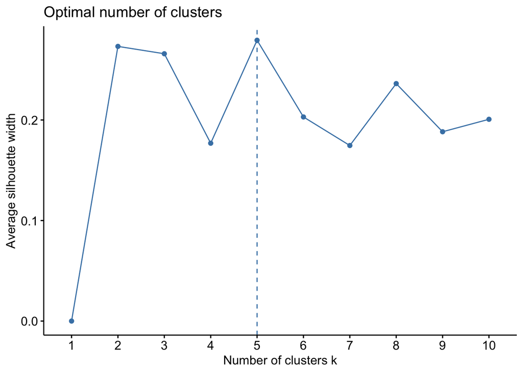

```r
fviz_nbclust(pharma_range, FUN = kmeans, method = "silhouette")
```

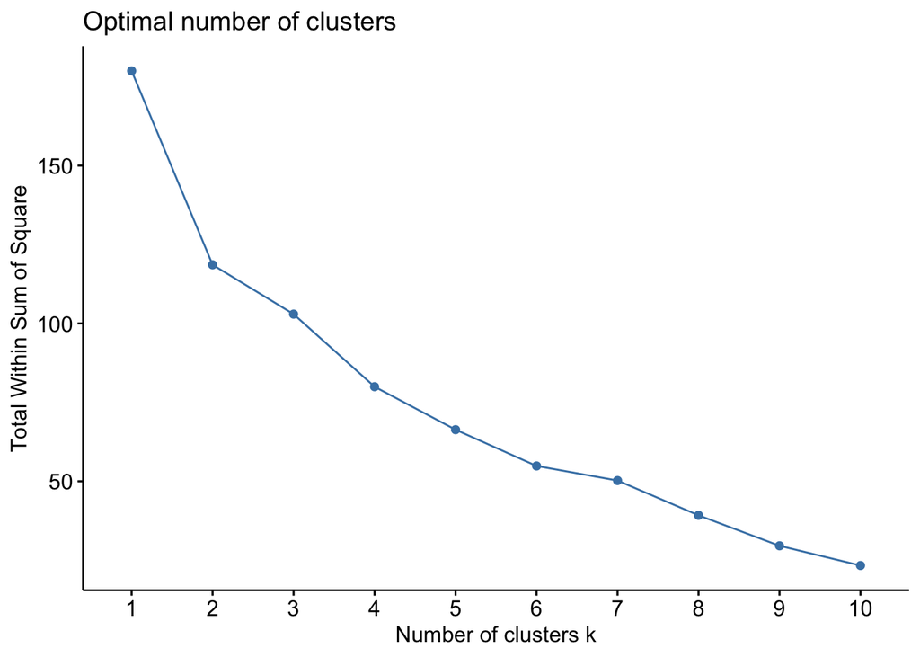

```r
fviz_nbclust(pharma_range, kmeans, method = "wss")
```

```r
set.seed(11)
cluster2 = kcca(pharma_scaled, k=3, kccaFamily("kmeans"))
cluster2
```

```
## kcca object of family 'kmeans'
##
## call:
## kcca(x = pharma_scaled, k = 3, family = kccaFamily("kmeans"))
##
## cluster sizes:
##
##  1  2  3
##  4 13  4
```

```r
clusters(cluster2)
```

```
##  [1] 2 1 2 2 2 1 2 1 2 2 3 2 3 2 3 2 3 1 2 2 2
```

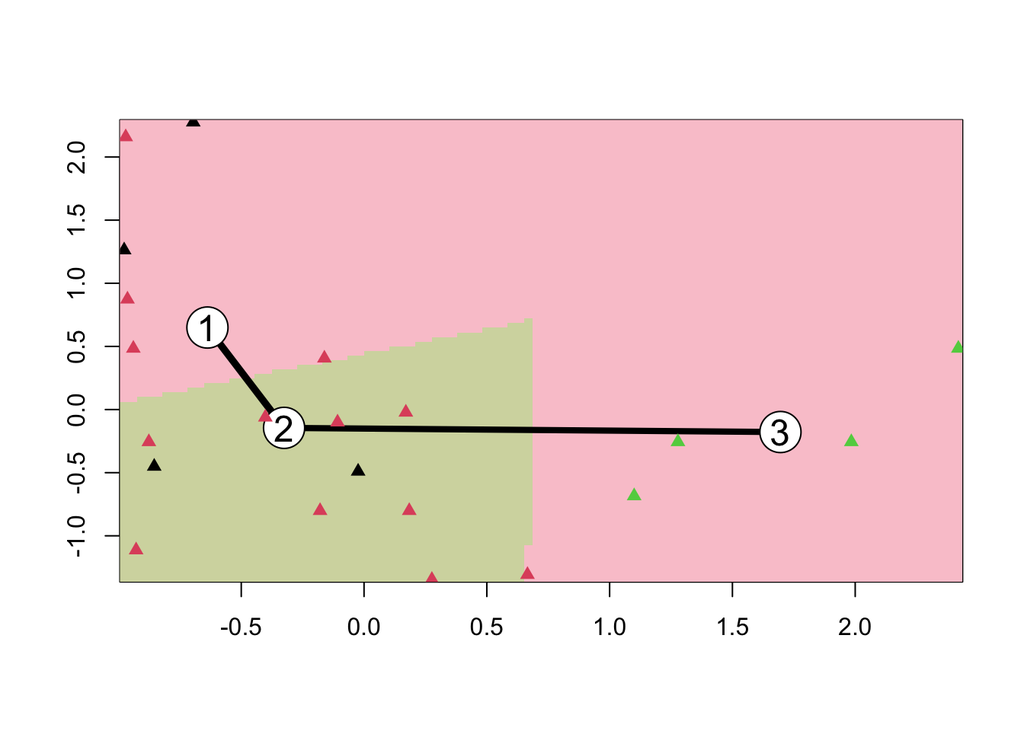

```r
#Apply the predict() function
clusters_index <- predict(cluster2)
image(cluster2)
points(pharma_scaled, col=clusters_index, pch=17, cex=1.0)
```

To run kmeans cluster on k =3, we use the kcca algorithm instead of kmeans from basic R.

```r
set.seed(11)
cluster2 = kcca(pharma_scaled, k=3, kccaFamily("kmedians"))
cluster2
```

```
## kcca object of family 'kmedians'
##
## call:
## kcca(x = pharma_scaled, k = 3, family = kccaFamily("kmedians"))
##
## cluster sizes:
##
## 1 2 3
## 9 8 4
```

```r
clusters(cluster2)
```

```
##  [1] 2 1 1 2 2 1 2 1 1 2 3 1 3 1 3 2 3 1 2 1 2
```

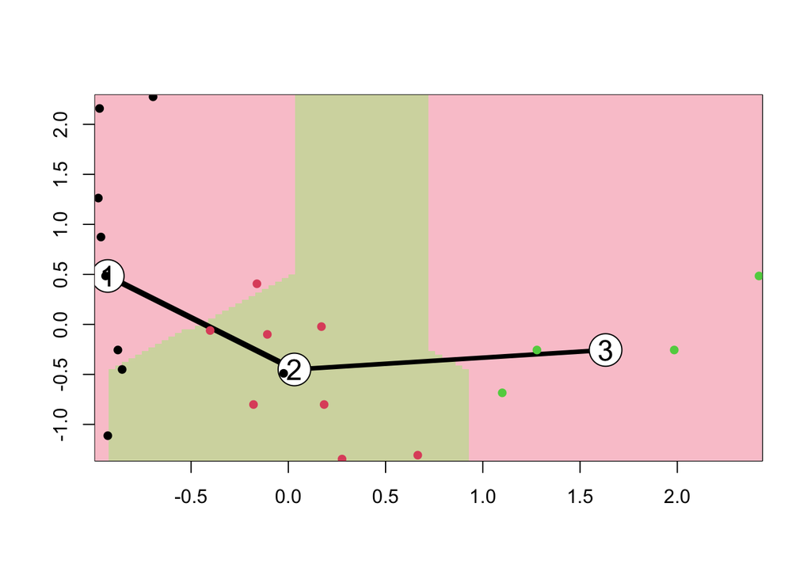

```r
#Apply the predict() function
clusters_index <- predict(cluster2)
image(cluster2)
points(pharma_scaled, col=clusters_index, pch=16, cex=1.0)
```